# Establishing atttiudes towards novel stimuli via the IAT

Experiment 4

Ian Hussey[^1]

29 September 2017

# 1 Descriptive statistics

## 1.1 Full sample

### 1.1.1 Age

|  | n | mean | sd |
| --- | --- | --- | --- |
| age | 328 | 35.79573 | 11.96188 |

### 1.1.2 Gender

| gender | n |
| --- | --- |
| 44 | 1 |
| femal | 1 |
| female | 142 |
| genderfluid | 1 |
| male | 182 |
| woman | 1 |

## 1.2 Analytic sample

I.e., after applying inclusion/exclusion criteria.

### 1.2.1 Conditions

| IAT_condition | n |
| --- | --- |
| Flowers-Chinese IAT | 166 |
| Insects-Chinese IAT | 150 |

| rmts_mastery | n |
| --- | --- |
| fail | 298 |
| pass | 18 |

| interaction(IAT_condition, rmts_mastery) | n |
| --- | --- |
| Flowers-Chinese IAT.fail | 156 |
| Insects-Chinese IAT.fail | 142 |
| Flowers-Chinese IAT.pass | 10 |
| Insects-Chinese IAT.pass | 8 |

### 1.2.2 Performance on the IAT and SC-IAT

| n | mean | sd |
| --- | --- | --- |
| 316 | 784.65 | 182.78 |
| 316 | 93.52 | 5.27 |
| 316 | 662.52 | 138.53 |
| 316 | 94.59 | 4.92 |

# 2 H1: Differences in SCIAT effects between IAT conditions

SCIAT effects differ between the IAT conditions, where the Chinese characters acquire the opposite valence to the images they were contrasted with in the IAT. This replicates the basic effect found in previous experiments (i.e., evaluative learning via the IAT).

## 2.1 Hypothesis test

```r
attach(passers_df)

t.test(formula = SCIAT_D1 ~ IAT_condition,
       alternative = "two.sided",
       paired = FALSE)
```

```
##
##  Welch Two Sample t-test
##
## data:  SCIAT_D1 by IAT_condition
## t = -3.7298, df = 304.29, p-value = 0.0002286
## alternative hypothesis: true difference in means is not equal to 0
## 95 percent confidence interval:
##  -0.16703050 -0.05165432
## sample estimates:
## mean in group Flowers-Chinese IAT mean in group Insects-Chinese IAT
##                       -0.07760241                        0.03174000
```

```r
cohen.d(SCIAT_D1 ~ IAT_condition,
        paired = FALSE)
```

```
##
## Cohen's d
##
## d estimate: -0.4218234 (small)
## 95 percent confidence interval:
##        inf        sup
## -0.6459193 -0.1977276
```

Positive *D*1 scores refer to more positive evaluations of the Chinese characters.

# 3 H2: SCIAT effects predicted by the interaction between IAT condition and passing the RMTS

The effect described in H1 is driven by a subgroup of individuals that can analogically relate the stimuli.

## 3.1 Hypothesis test

Hypothesis refers to the interaction effect.

```r
model_2 <- lm(SCIAT_D1 ~ IAT_condition * rmts_mastery,
              contrasts = list(IAT_condition = "contr.sum", rmts_mastery = "contr.sum"),
              data = passers_df)

# anova summary
Anova(model_2, type = 3)
```

```
## Anova Table (Type III tests)
##
## Response: SCIAT_D1
##                             Sum Sq  Df F value  Pr(>F)
## (Intercept)                 0.0835   1  1.2356 0.26718
## IAT_condition               0.2478   1  3.6670 0.05641 .
## rmts_mastery                0.0131   1  0.1940 0.65990
## IAT_condition:rmts_mastery  0.0033   1  0.0484 0.82594
## Residuals                  21.0802 312
## ---
## Signif. codes:  0 '***' 0.001 '**' 0.01 '*' 0.05 '.' 0.1 ' ' 1
```

```r
# partial eta squared
model_2 %>%
  etaSquared() %>%
  as.data.frame() %>%
  round_df(3)
```

```
##                            eta.sq eta.sq.part
## IAT_condition               0.043       0.043
## rmts_mastery                0.001       0.001
## IAT_condition:rmts_mastery  0.000       0.000
```

## 3.2 Effects table

|  |  | B | CI | std. Beta | CI | p |
| --- | --- | --- | --- | --- | --- | --- |
| (Intercept) |  | -0.04 | -0.10 – 0.03 |  |  | .267 |
| IAT_condition1 |  | -0.06 | -0.12 – 0.00 | -0.23 | -0.46 – 0.01 | .056 |
| rmts_mastery1 |  | 0.01 | -0.05 – 0.08 | 0.02 | -0.08 – 0.13 | .660 |
| IAT_condition1:rmts_mastery1 |  | 0.01 | -0.06 – 0.07 | 0.03 | -0.21 – 0.26 | .826 |
| Observations |  | 316 |  |  |  |  |
| R<sup>2</sup> / adj. R<sup>2</sup> |  | .044 / .034 |  |  |  |  |

## 3.3 Effects plot

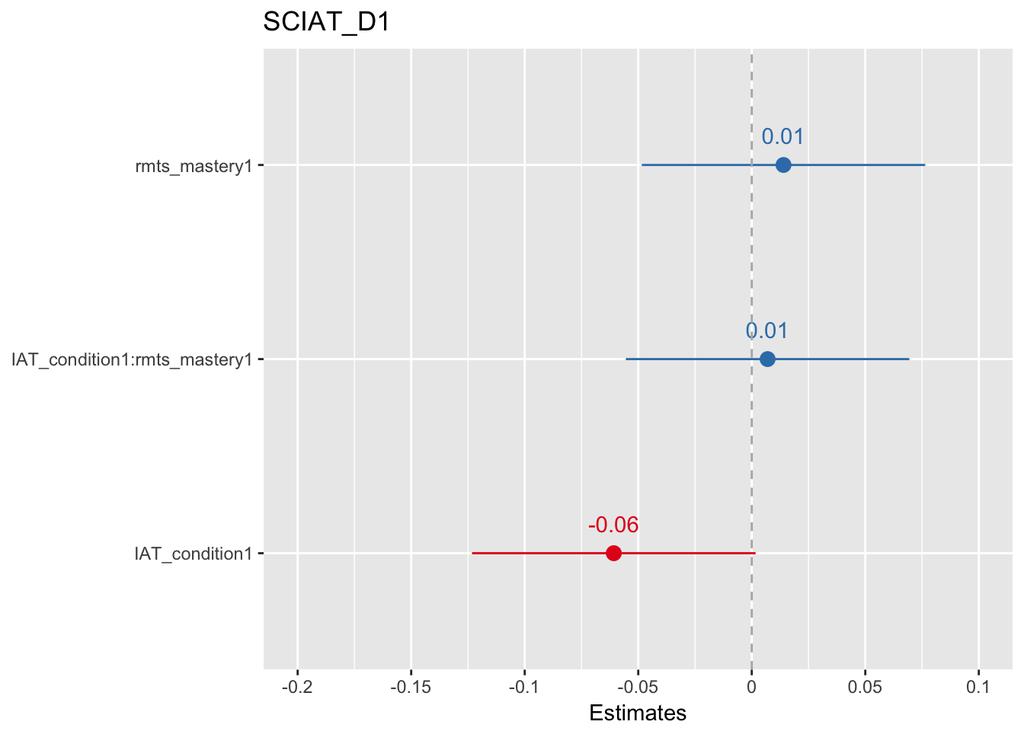

## 3.4 Greyscale inference plot

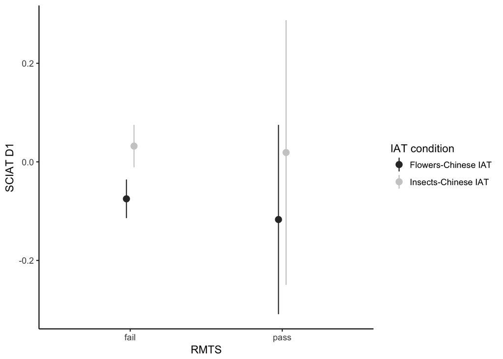

```r
SCIAT_summary_data <- passers_df %>%
  group_by(IAT_condition, rmts_mastery) %>%
  dplyr::summarize(mean_SCIAT_D1 = round(mean(SCIAT_D1), 3),
                   se_SCIAT_D1 = round(std.error(SCIAT_D1), 3)) %>%
  dplyr::rename(`IAT condition` = IAT_condition)

ggplot(data = SCIAT_summary_data,
       aes(x = rmts_mastery, y = mean_SCIAT_D1, colour = `IAT condition`)) +
  geom_pointrange(aes(ymax = mean_SCIAT_D1 + (1.96*se_SCIAT_D1),
                    ymin = mean_SCIAT_D1 + (-1.96*se_SCIAT_D1)),
                position = position_dodge(width = .1)) +
  # geom_line(aes(group = `IAT condition`),
  #           position = position_dodge(width = .1)) +
  ylab("SCIAT D1") +
  xlab("RMTS") +
  scale_colour_grey() +
  theme_classic()
```

# 4 Exploratory test 1: H2 is moderated by task order

It is possible that the rmts provided a training context as well as a testing context. The task order might therefore influence the results. This test has been included as a post hoc exploratory test. However, the N per cell is very low, and results should be interpreted with much caution.

Hypothesis refers to the interaction effect.

```r
e_model_1 <- lm(SCIAT_D1 ~ IAT_condition * rmts_mastery * task_order,
              contrasts = list(IAT_condition = "contr.sum",
                               rmts_mastery = "contr.sum",
                               task_order = "contr.sum"),
              data = passers_df)

# anova summary
Anova(e_model_1, type = 3)
```

```
## Anova Table (Type III tests)
##
## Response: SCIAT_D1
##                                        Sum Sq  Df F value  Pr(>F)
## (Intercept)                            0.0352   1  0.5272 0.46835
## IAT_condition                          0.1486   1  2.2274 0.13660
## rmts_mastery                           0.0020   1  0.0298 0.86302
## task_order                             0.0993   1  1.4877 0.22351
## IAT_condition:rmts_mastery             0.0003   1  0.0044 0.94710
## IAT_condition:task_order               0.2653   1  3.9759 0.04704 *
## rmts_mastery:task_order                0.1284   1  1.9250 0.16631
## IAT_condition:rmts_mastery:task_order  0.3519   1  5.2746 0.02231 *
## Residuals                             20.5484 308
## ---
## Signif. codes:  0 '***' 0.001 '**' 0.01 '*' 0.05 '.' 0.1 ' ' 1
```

```r
# partial eta squared
e_model_1 %>%
  etaSquared() %>%
  as.data.frame() %>%
  round_df(3)
```

```
##                                       eta.sq eta.sq.part
## IAT_condition                          0.045       0.046
## rmts_mastery                           0.001       0.001
## task_order                             0.000       0.000
## IAT_condition:rmts_mastery             0.001       0.002
## IAT_condition:task_order               0.000       0.000
## rmts_mastery:task_order                0.008       0.009
## IAT_condition:rmts_mastery:task_order  0.016       0.017
```

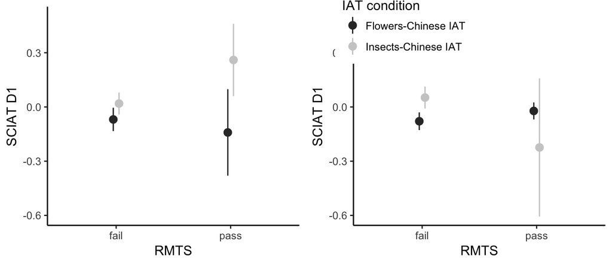

```r
rmts_first_group <- passers_df %>%
  filter(task_order == "rmts first") %>%
  group_by(IAT_condition, rmts_mastery) %>%
  dplyr::summarize(mean_SCIAT_D1 = round(mean(SCIAT_D1), 3),
                   se_SCIAT_D1 = round(std.error(SCIAT_D1), 3)) %>%
  dplyr::rename(`IAT condition` = IAT_condition)

p1 <-
  ggplot(data = rmts_first_group,
       aes(x = rmts_mastery, y = mean_SCIAT_D1, colour = `IAT condition`)) +
  geom_pointrange(aes(ymax = mean_SCIAT_D1 + (1.96*se_SCIAT_D1),
                    ymin = mean_SCIAT_D1 + (-1.96*se_SCIAT_D1)),
                position = position_dodge(width = .1)) +
  # geom_line(aes(group = `IAT condition`),
  #           position = position_dodge(width = .1)) +
  ylab("SCIAT D1") +
  xlab("RMTS") +
  scale_colour_grey() +
  theme_classic() +
  coord_cartesian(ylim = c(-.6, .5)) +
  theme(legend.position = "none")

rmts_second_group <- passers_df %>%
  filter(task_order == "evaluation tasks first") %>%
  group_by(IAT_condition, rmts_mastery) %>%
  dplyr::summarize(mean_SCIAT_D1 = round(mean(SCIAT_D1), 3),
                   se_SCIAT_D1 = round(std.error(SCIAT_D1), 3)) %>%
  dplyr::rename(`IAT condition` = IAT_condition)

p2 <-
  ggplot(data = rmts_second_group,
       aes(x = rmts_mastery, y = mean_SCIAT_D1, colour = `IAT condition`)) +
  geom_pointrange(aes(ymax = mean_SCIAT_D1 + (1.96*se_SCIAT_D1),
                    ymin = mean_SCIAT_D1 + (-1.96*se_SCIAT_D1)),
                position = position_dodge(width = .1)) +
  # geom_line(aes(group = `IAT condition`),
  #           position = position_dodge(width = .1)) +
  ylab("SCIAT D1") +
  xlab("RMTS") +
  scale_colour_grey() +
  theme_classic() +
  coord_cartesian(ylim = c(-.6, .5)) +
  theme(legend.position = c(.2, .9))

grid.arrange(p1, p2, ncol = 2)
```

# 5 H3: Differences in ratings between IAT conditions

## 5.1 Hypothesis test

```r
t.test(formula = mean_rating ~ IAT_condition,
       alternative = "two.sided",
       paired = FALSE)
```

```
##
##  Welch Two Sample t-test
##
## data:  mean_rating by IAT_condition
## t = -1.408, df = 313.8, p-value = 0.1601
## alternative hypothesis: true difference in means is not equal to 0
## 95 percent confidence interval:
##  -0.30691836  0.05088141
## sample estimates:
## mean in group Flowers-Chinese IAT mean in group Insects-Chinese IAT
##                          4.242048                          4.370067
```

```r
cohen.d(mean_rating ~ IAT_condition,
        paired = FALSE)
```

```
##
## Cohen's d
##
## d estimate: -0.1575961 (negligible)
## 95 percent confidence interval:
##         inf         sup
## -0.37958975  0.06439751
```

Positive ratings refer to more positive evaluations of the Chinese characters.

# 6 H4: Ratings predicted by the interaction between IAT condition and passing the RMTS

The effect described in H3 is driven by a subgroup of individuals that can analogically relate the stimuli.

## 6.1 Hypothesis test

Hypothesis refers to the interaction effect.

```r
model_4 <- lm(mean_rating ~ IAT_condition * rmts_mastery,
              contrasts = list(IAT_condition = "contr.sum", rmts_mastery = "contr.sum"),
              data = passers_df)

# anova summary
Anova(model_4, type = 3)
```

```
## Anova Table (Type III tests)
##
## Response: mean_rating
##                             Sum Sq  Df   F value  Pr(>F)
## (Intercept)                1227.59   1 1875.1320 < 2e-16 ***
## IAT_condition                 3.95   1    6.0302 0.01461 *
## rmts_mastery                  0.08   1    0.1187 0.73067
## IAT_condition:rmts_mastery    2.73   1    4.1694 0.04200 *
## Residuals                   204.26 312
## ---
## Signif. codes:  0 '***' 0.001 '**' 0.01 '*' 0.05 '.' 0.1 ' ' 1
```

```r
# partial eta squared
model_4 %>%
  etaSquared() %>%
  as.data.frame() %>%
  round_df(3)
```

```
##                            eta.sq eta.sq.part
## IAT_condition               0.006       0.006
## rmts_mastery                0.001       0.001
## IAT_condition:rmts_mastery  0.013       0.013
```

## 6.2 Effects table

|  |  | B | CI | std. Beta | CI | p |
| --- | --- | --- | --- | --- | --- | --- |
| (Intercept) |  | 4.28 | 4.08 – 4.47 |  |  | <.001 |
| IAT_condition1 |  | -0.24 | -0.44 – -0.05 | -0.30 | -0.54 – -0.06 | .015 |
| rmts_mastery1 |  | 0.03 | -0.16 – 0.23 | 0.02 | -0.09 – 0.13 | .731 |
| IAT_condition1:rmts_mastery1 |  | 0.20 | 0.01 – 0.40 | 0.25 | 0.01 – 0.49 | .042 |
| Observations |  | 316 |  |  |  |  |
| R<sup>2</sup> / adj. R<sup>2</sup> |  | .020 / .011 |  |  |  |  |

## 6.3 Effects plot

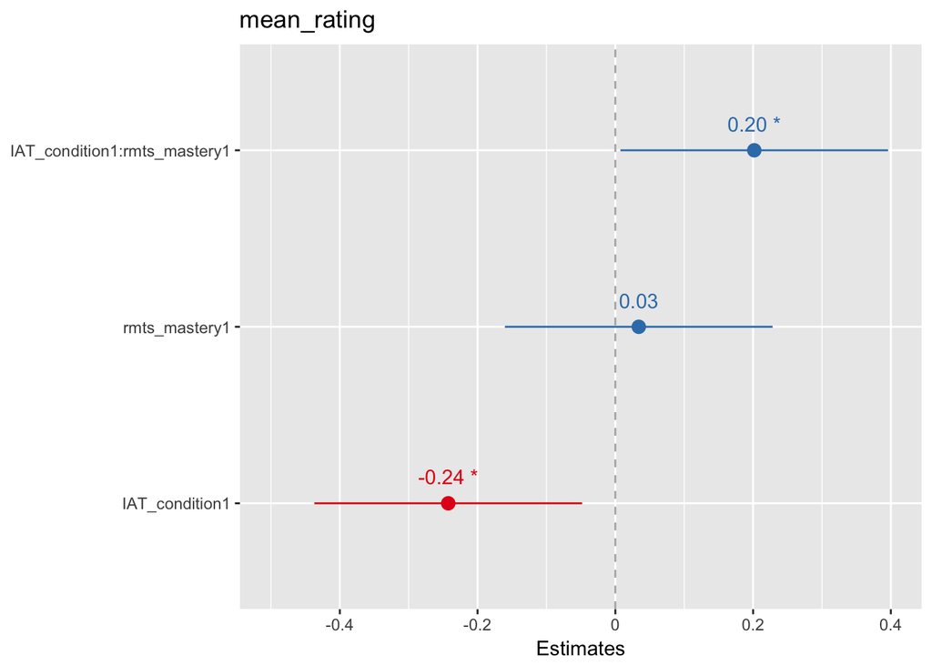

## 6.4 Greyscale inference plot

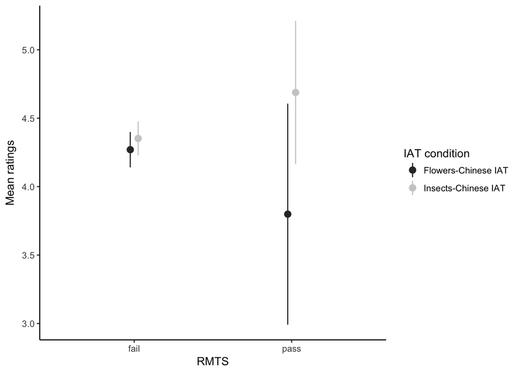

```r
ratings_summary_data <- passers_df %>%
  group_by(IAT_condition, rmts_mastery) %>%
  dplyr::summarize(mean_mean_rating = round(mean(mean_rating), 3),
                   se_mean_rating = round(std.error(mean_rating), 3)) %>%
  dplyr::rename(`IAT condition` = IAT_condition)

ggplot(data = ratings_summary_data,
       aes(x = rmts_mastery, y = mean_mean_rating, colour = `IAT condition`)) +
  geom_pointrange(aes(ymax = mean_mean_rating + (1.96*se_mean_rating),
                      ymin = mean_mean_rating + (-1.96*se_mean_rating)),
                  position = position_dodge(width = .1)) +
  # geom_line(aes(group = `IAT condition`),
  #           position = position_dodge(width = .1)) +
  ylab("Mean ratings") +
  xlab("RMTS") +
  scale_colour_grey() +
  theme_classic()
```

# 7 Exploratory test 2: H4 is moderated by task order

It is possible that the rmts provided a training context as well as a testing context. The task order might therefore influence the results. This test has been included as a post hoc exploratory test. However, the N per cell is very low, and results should be interpreted with much caution.

Hypothesis refers to the interaction effect.

```r
e_model_2 <- lm(mean_rating ~ IAT_condition * rmts_mastery * task_order,
              contrasts = list(IAT_condition = "contr.sum",
                               rmts_mastery = "contr.sum",
                               task_order = "contr.sum"),
              data = passers_df)

# anova summary
Anova(e_model_2, type = 3)
```

```
## Anova Table (Type III tests)
##
## Response: mean_rating
##                                        Sum Sq  Df   F value    Pr(>F)
## (Intercept)                           1063.75   1 1694.3301 < 2.2e-16 ***
## IAT_condition                            0.46   1    0.7288  0.393941
## rmts_mastery                             0.95   1    1.5069  0.220552
## task_order                               4.05   1    6.4565  0.011545 *
## IAT_condition:rmts_mastery               0.06   1    0.0965  0.756270
## IAT_condition:task_order                 6.03   1    9.6018  0.002123 **
## rmts_mastery:task_order                  1.87   1    2.9737  0.085633 .
## IAT_condition:rmts_mastery:task_order    3.97   1    6.3202  0.012447 *
## Residuals                              193.37 308
## ---
## Signif. codes:  0 '***' 0.001 '**' 0.01 '*' 0.05 '.' 0.1 ' ' 1
```

```r
# partial eta squared
e_model_2 %>%
  etaSquared() %>%
  as.data.frame() %>%
  round_df(3) %>%
  kable()
```

|  | eta.sq | eta.sq.part |
| --- | --- | --- |
| IAT_condition | 0.008 | 0.008 |
| rmts_mastery | 0.000 | 0.000 |
| task_order | 0.016 | 0.017 |
| IAT_condition:rmts_mastery | 0.004 | 0.004 |
| IAT_condition:task_order | 0.011 | 0.012 |
| rmts_mastery:task_order | 0.007 | 0.007 |
| IAT_condition:rmts_mastery:task_order | 0.019 | 0.020 |

## 7.1 Greyscale inference plot

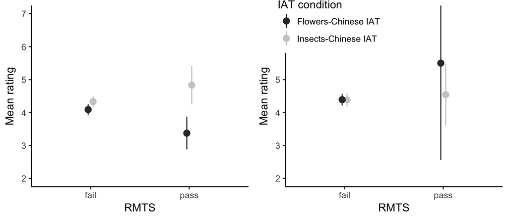

```r
rmts_first_group_ratings <- passers_df %>%
  filter(task_order == "rmts first") %>%
  group_by(IAT_condition, rmts_mastery) %>%
  dplyr::summarize(mean_mean_rating = round(mean(mean_rating), 3),
                   se_mean_rating = round(std.error(mean_rating), 3)) %>%
  dplyr::rename(`IAT condition` = IAT_condition)

p3 <-
  ggplot(data = rmts_first_group_ratings,
       aes(x = rmts_mastery, y = mean_mean_rating, colour = `IAT condition`)) +
  geom_pointrange(aes(ymax = mean_mean_rating + (1.96*se_mean_rating),
                    ymin = mean_mean_rating + (-1.96*se_mean_rating)),
                position = position_dodge(width = .1)) +
  # geom_line(aes(group = `IAT condition`),
  #           position = position_dodge(width = .1)) +
  ylab("Mean rating") +
  xlab("RMTS") +
  scale_colour_grey() +
  theme_classic() +
  coord_cartesian(ylim = c(2, 7)) +
  theme(legend.position="none")

rmts_second_group_ratings <- passers_df %>%
  filter(task_order == "evaluation tasks first") %>%
  group_by(IAT_condition, rmts_mastery) %>%
  dplyr::summarize(mean_mean_rating = round(mean(mean_rating), 3),
                   se_mean_rating = round(std.error(mean_rating), 3)) %>%
  dplyr::rename(`IAT condition` = IAT_condition)

p4 <-
  ggplot(data = rmts_second_group_ratings,
       aes(x = rmts_mastery, y = mean_mean_rating, colour = `IAT condition`)) +
  geom_pointrange(aes(ymax = mean_mean_rating + (1.96*se_mean_rating),
                    ymin = mean_mean_rating + (-1.96*se_mean_rating)),
                position = position_dodge(width = .1)) +
  # geom_line(aes(group = `IAT condition`),
  #           position = position_dodge(width = .1)) +
  ylab("Mean rating") +
  xlab("RMTS") +
  scale_colour_grey() +
  theme_classic() +
  coord_cartesian(ylim = c(2, 7)) +
  theme(legend.position = c(.2, .9))

grid.arrange(p3, p4, ncol = 2)
```

[^1]: Ghent University. Email: ian.hussey@ugent.be